# Introduction to Biostatistics

# 1 Learning objectives

## 1.1 Learning objectives

- **Describe** *maximum likelihood estimation* for linear regression
- **Describe** *hypothesis testing* for linear regression coefficients, including the sampling distribution used and degrees of freedom

# 2 Estimation

## 2.1 What is estimation?

- Method by which we get **estimates** of regression coefficients
- What are the $b_0$ and $b_1$ for the regression equation?

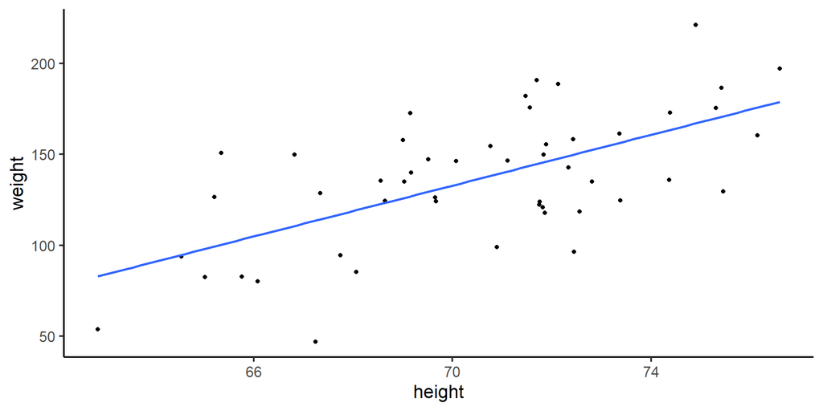

```r
height <- 3*rnorm(50) + 70
weight <- 7 * (height - 70) + 25 * rnorm(50) + 125
dat <- data.frame(height, weight)
ggplot(data = dat, aes(x = height, y = weight)) +
  geom_point() +
  geom_smooth(method = "lm", se = FALSE)
```

## 2.2 Ordinary least squares (OLS) estimation

- **Minimize** the sum of **squared** residuals
- Find $b_0$ and $b_1$ that give the smallest $\Sigma((Y_i - \hat{Y}_1)^2)$
- For linear regression, there is **one** value of $b_0$ and **one** value of $b_1$ that minimize the sum of squared residuals
  - Not true for all estimation methods

## 2.3 Minimizing

- Functions with squared in them look like a “U”
- Minimum is the bottom of the “U”
- **Tangent line** is a line that touches a curve *at a single point*
  - The **slope** of the tangent line is 0 at the **minimum**
- $Y = X^2$

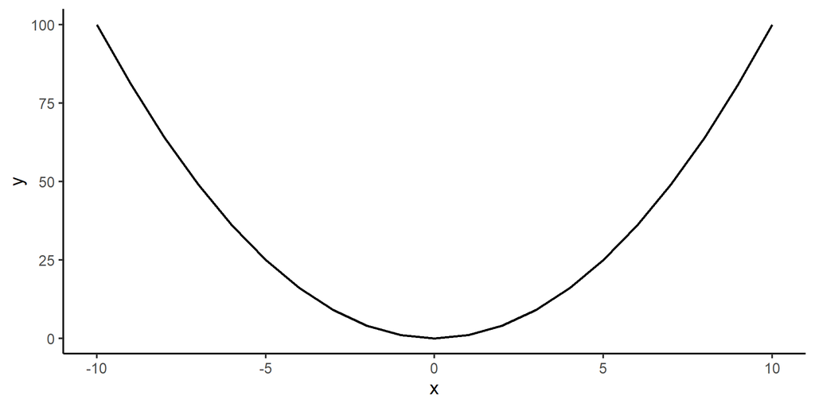

```r
x <- c(-10:10)
y <- x*x
dat1 <- data.frame(x, y)
ggplot(data = dat1, aes(x = x, y = y)) +
  geom_line(linewidth = 1)
```

## 2.4 Tangent lines

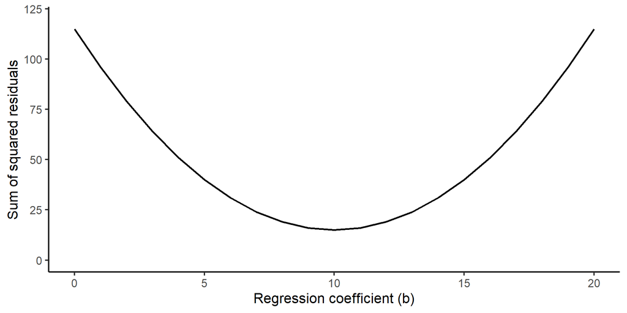

```r
b1 <- c(0:20)
ssr <- b1*b1 - 20*b1 + 115
dat_ssr <- data.frame(b1, ssr)
ggplot(data = dat_ssr, aes(x = b1, y = ssr)) +
  geom_line(linewidth = 1) +
  ylim(0, 120) +
  labs(x = "Regression coefficient (b)", y = "Sum of squared residuals")
```

## 2.5 Tangent lines (at b = 15)

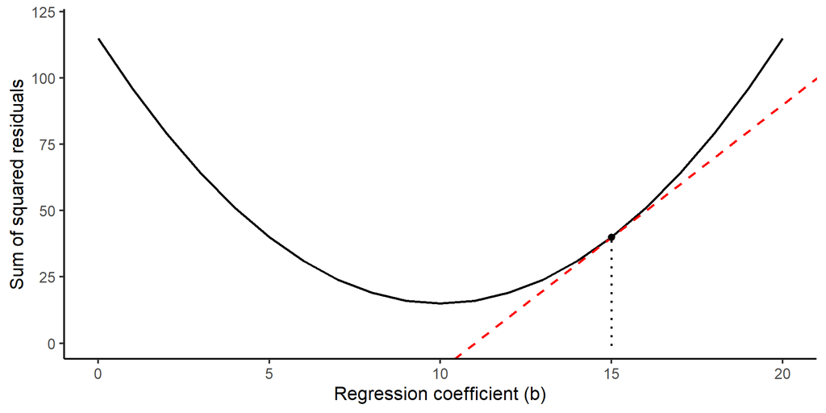

```r
ggplot(data = dat_ssr, aes(x = b1, y = ssr)) +
  geom_line(linewidth = 1) +
  ylim(0, 120) +
  labs(x = "Regression coefficient (b)", y = "Sum of squared residuals") +
  geom_abline(intercept = -110, slope = 10, linewidth = 1, linetype = "dashed", color = "red") +
  annotate("pointrange", x = 15, y = 15*15 - 20*15 + 115, ymin = 15*15 - 20*15 + 115, ymax = 15*15 - 20*15 + 115) +
  geom_segment(x = 15, xend = 15, y = -1, yend = 15*15 - 20*15 + 115, linetype = "dotted", linewidth = 1)
```

## 2.6 Tangent lines (at b = 12)

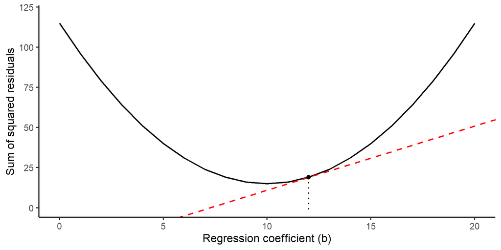

```r
ggplot(data = dat_ssr, aes(x = b1, y = ssr)) +
  geom_line(linewidth = 1) +
  ylim(0, 120) +
  labs(x = "Regression coefficient (b)", y = "Sum of squared residuals") +
  geom_abline(intercept = -29, slope = 4, linewidth = 1, linetype = "dashed", color = "red") +
  annotate("pointrange", x = 12, y = 12*12 - 20*12 + 115, ymin = 12*12 - 20*12 + 115, ymax = 12*12 - 20*12 + 115) +
  geom_segment(x = 12, xend = 12, y = -1, yend = 12*12 - 20*12 + 115, linetype = "dotted", linewidth = 1)
```

## 2.7 Tangent lines (at b = 10)

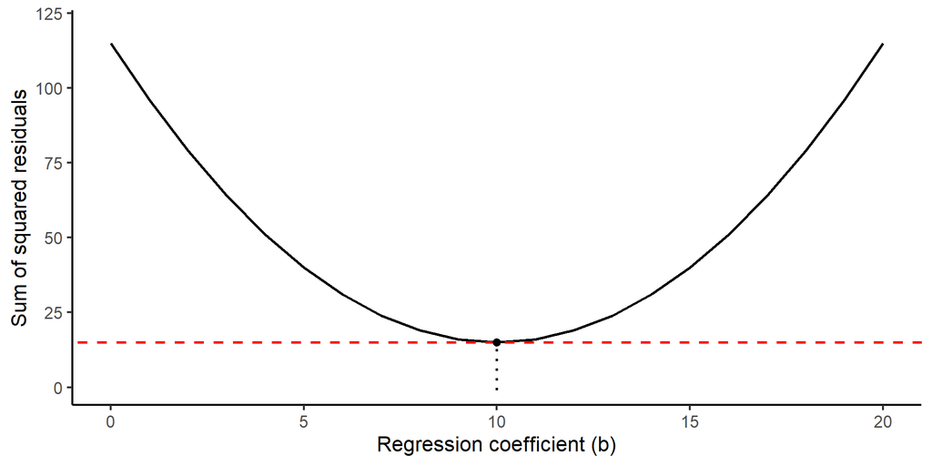

```r
ggplot(data = dat_ssr, aes(x = b1, y = ssr)) +
  geom_line(linewidth = 1) +
  ylim(0, 120) +
  labs(x = "Regression coefficient (b)", y = "Sum of squared residuals") +
  geom_abline(intercept = 15, slope = 0, linewidth = 1, linetype = "dashed", color = "red") +
  annotate("pointrange", x = 10, y = 10*10 - 20*10 + 115, ymin = 10*10 - 20*10 + 115, ymax = 10*10 - 20*10 + 115) +
  geom_segment(x = 10, xend = 10, y = -1, yend = 10*10 - 20*10 + 115, linetype = "dotted", linewidth = 1)
```

## 2.8 Tangents and minimums

- The tangent line is **horizontal** (slope = 0) at the **minimum**
- Want to find the **minimum** of the *sum of squared residuals*
- **Value of regression coefficient** that meets the *least squares criterion*
- Use calculus: **Derivative** of a function produces the *tangent line*

## 2.9 Least squares solution

1. State **function** to minimize: $\Sigma((Y_i - \hat{Y}_i)^2)$
2. Take **derivative** of the function, with respect to the *constants of interest* (i.e., $b_0$ and $b_1$)
3. Set the derivative **equal to 0**: Normal equation
4. **Solve** for the *constants*

## 2.10 1. Function to minimize

$$\Sigma(Y_i - \hat{Y}_i)^2 =$$

$$\Sigma(Y - (b_1 X + b_0))^2 =$$
$$\Sigma(Y - b_1 X - b_0)^2 =$$
$$\Sigma(Y^2 + {b^2_0} + {b^2_1} X^2 - 2 b_0 Y - 2 b_1 X Y + 2 b_0 b_1 X ) =$$
$$\Sigma Y^2 + \Sigma{b^2_0} + \Sigma{b^2_1} X^2 - \Sigma 2 b_0 Y - \Sigma 2 b_1 X Y + \Sigma 2 b_0 b_1 X =$$
$$\Sigma Y^2 + n{b^2_0} + {b^2_1} \Sigma X^2 - 2 b_0 \Sigma Y - 2 b_1 \Sigma X Y + 2 b_0 b_1 \Sigma X$$

## 2.11 2. Get the derivative

- With respect to $b_1$:

$$\frac{\partial \Sigma (Y - \hat{Y})^2}{\partial b_1} = 2 b_1 \Sigma X^2 - 2 \Sigma X Y + 2 b_0 \Sigma X$$

- With respect to $b_0$:

$$\frac{\partial \Sigma (Y - \hat{Y})^2}{\partial b_0} = 2 n b_0 - 2 \Sigma Y + 2 b_1 \Sigma X$$

## 2.12 3 and 4. Set to 0 and solve

For $b_1$:

$$2 b_1 \Sigma X^2 - 2 \Sigma X Y + 2 b_0 \Sigma X = 0$$
$$\vdots$$
$$b_1 = \frac{n \Sigma X Y - (\Sigma X) (\Sigma Y)}{n \Sigma X^2 - (\Sigma X)^2} = \frac{SP_{XY}}{SS_X} = \frac{s_{XY}}{{s^2_X}}$$

## 2.13 3 and 4. Set to 0 and solve

For $b_0$:

$$2 n b_0 - 2 \Sigma Y + 2 b_1 \Sigma X = 0$$
$$\vdots$$
$$b_0 = \overline{Y} - b_1 \overline{X}$$

## 2.14 How one variable **varies**

- Variation = **sum** of **squared deviations** from the **mean**
  - $SS_X = \Sigma((X - \bar{X})^2)$
- Variance = **variation** divided by $n - 1$
  - $s^2_X = \frac{SS_X}{n-1}$
- Standard deviation = **square root** of **variance**
  - $s_X = \sqrt{s^2_X}$

## 2.15 How two variables **covary**

- Covariation = **sum** of **product of deviations** from the **mean**
  - $SP_{XY} = \Sigma((X - \bar{X})(Y - \bar{Y}))$
- Covariance = **covariation** divided by $n - 1$
  - $s_{XY} = \frac{SP_{XY}}{n-1}$

## 2.16 Least squares estimates

- $b_1$ is the
  - **Covariation** between X and Y, divided by the **variation** of X
  - **Covariance** between X and Y, divided by the **variance** of X

$$b_1 = \frac{SP_{XY}}{SS_X} = \frac{s_{XY}}{{s^2_X}}$$

$$b_0 = \overline{Y} - b_1 \overline{X}$$

## 2.17 Aside: $R^2_{multiple}$

- $R^2$ = proportion of variation in $Y$ that’s explained by the predictors
  - Also: Maximum possible squared correlation between $Y$ and $\hat{Y}$

$$R^2_{multiple} = r^2_{Y\hat{Y}} = \frac{SS_{regression}}{SS_Y} = \frac{predictable\ variation}{total\ variation}$$

where $SS_{regression} = \Sigma(\hat{Y_i} - \overline{Y}_i)^2$

## 2.18 How do we really estimate?

- Maximum likelihood (ML)
  - **Maximizes** a likelihood function
  - Makes **assumptions** about the distribution of parameter

## 2.19 Likelihood

- **Conceptually** similar to *probability*
  - Higher values are more likely / probable
  - Likelihood = **relative** probability
- Make **assumptions** about the distribution of observations
  - For example, that they’re **normally distributed**
  - Use (normal) **probability distributions** to create a likelihood function

## 2.20 Recall: Normal distribution

$$f(X) = \frac{1}{\sqrt{2\pi\sigma^2}}e^{-\frac{(X - \mu)^2}{2\sigma^2}}$$

- $\mu$ = mean = location of the distribution
- $\sigma^2$ = variance = spread of the distribution
  - $\sigma$ = standard deviation

## 2.21 Likelihood for one subject

- Make **assumptions** about the **population distribution**
- Assume outcome (BDI) has mean = 20, SD = 5
- For a single subject with BDI = 21:
  - $L_i = \frac{1}{\sqrt{2\pi\sigma^2}}e^{-\frac{(X - \mu)^2}{2\sigma^2}} = \frac{1}{\sqrt{2\pi*5^2}}e^{-\frac{(21 - 20)^2}{2*5^2}} = 0.078$
- $L_i$ = 0.078 is the **likelihood** or **relative probability** of X = 21 from a normally distributed population with mean = 20 and SD = 5

## 2.22 Subject likelihoods

- Small example from Enders (2005)
- Assume $\mu$ = 20, $\sigma$ = 5

```r
ID <- c(1:10)
BDI <- c(5, 33, 17, 21, 13, 17, 5, 13, 17, 13)
Likelihood <- dnorm(BDI, 20, 5)
LogLikelihood <- log(Likelihood)
LL_dat <- data.frame(ID, BDI, Likelihood, LogLikelihood)
round(LL_dat, 3)
```

```
   ID BDI Likelihood LogLikelihood
1   1   5      0.001        -7.028
2   2  33      0.003        -5.908
3   3  17      0.067        -2.708
4   4  21      0.078        -2.548
5   5  13      0.030        -3.508
6   6  17      0.067        -2.708
7   7   5      0.001        -7.028
8   8  13      0.030        -3.508
9   9  17      0.067        -2.708
10 10  13      0.030        -3.508
```

## 2.23 Normal distribution, mean = 20, SD = 5

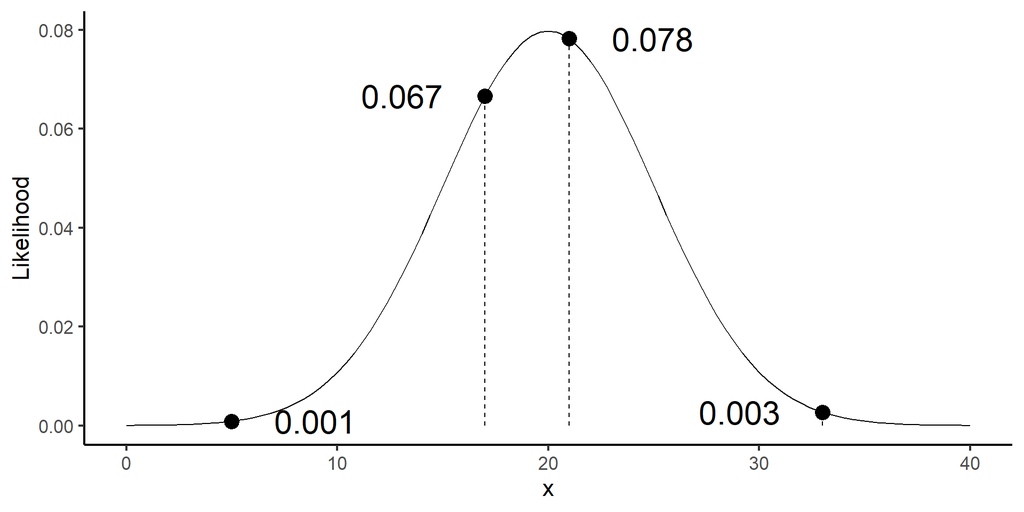

```r
norm_plot <- ggplot(data = data.frame(x = c(0, 40)), aes(x)) +
  stat_function(fun = dnorm, n = 101, args = list(mean = 20, sd = 5)) +
  ylab("Likelihood")
norm_plot +
  annotate("pointrange", x = LL_dat[4,2], y = LL_dat[4,3], ymin = LL_dat[4,3], ymax = LL_dat[4,3], size = 1) +
  annotate("text", x = LL_dat[4,2] + 2, y = LL_dat[4,3], label = "0.078", hjust = 0, size = 8) +
  geom_segment(x = LL_dat[4,2], xend = LL_dat[4,2], y = 0, yend = LL_dat[4,3], linetype = "dashed") +
  annotate("pointrange", x = LL_dat[2,2], y = LL_dat[2,3], ymin = LL_dat[2,3], ymax = LL_dat[2,3], size = 1) +
  annotate("text", x = LL_dat[2,2] - 2, y = LL_dat[2,3], label = "0.003", hjust = 1, size = 8) +
  geom_segment(x = LL_dat[2,2], xend = LL_dat[2,2], y = 0, yend = LL_dat[2,3], linetype = "dashed") +
  annotate("pointrange", x = LL_dat[3,2], y = LL_dat[3,3], ymin = LL_dat[3,3], ymax = LL_dat[3,3], size = 1) +
  annotate("text", x = LL_dat[3,2] - 2, y = LL_dat[3,3], label = "0.067", hjust = 1, size = 8) +
  geom_segment(x = LL_dat[3,2], xend = LL_dat[3,2], y = 0, yend = LL_dat[3,3], linetype = "dashed") +
  annotate("pointrange", x = LL_dat[1,2], y = LL_dat[1,3], ymin = LL_dat[1,3], ymax = LL_dat[1,3], size = 1) +
  annotate("text", x = LL_dat[1,2] + 2, y = LL_dat[1,3], label = "0.001", hjust = 0, size = 8) +
  geom_segment(x = LL_dat[1,2], xend = LL_dat[1,2], y = 0, yend = LL_dat[1,3], linetype = "dashed")
```

## 2.24 Likelihood for a sample

- Each subject has a likelihood for their observation
  - How to combine them?
- Probability theory: Joint probability of independent events is the **product** of the individual probabilities
  - Same works for likelihoods:

$$L = \prod_{i=1}^{n} L_i = L_1 \times L_2 \times L_3 \times \cdots \times L_n$$

## 2.25 What does likelihood mean?

- Individual
  - *Relatively* higher $L_i$ means that **that individual’s score** is **more likely** than **other scores** (given the distributional assumptions)
- Sample
  - *Relatively* higher $L$ means that **the sample’s scores** are **more likely** than **other samples of scores** (given the distributional assumptions)

## 2.26 Sample likelihood

- Sample likelihood for this **very small** sample

$$L = 0.001 \times 0.003 \times 0.067 \times 0.078 \times 0.030 \times 0.067 \times 0.001$$

$$\times 0.030 \times 0.067 \times 0.030 = 0.000000000000000001327$$

- Especially as $n$ increases: Very very very small number, rounding errors
  - Computers have problems with this

## 2.27 Log-likelihood

- Logarithms: $log(ab) = log(a) + log(b)$

$$L = \prod_{i=1}^{n} L_i = L_1 \times L_2 \times L_3 \times \cdots \times L_n$$
becomes

$$log(L) = \sum_{i=1}^{n} log(L_i) = log(L_1) + log(L_2) + log(L_3) + \cdots + log(L_n)$$

## 2.28 Log-likelihood

```r
round(LL_dat, 3)
```

```
   ID BDI Likelihood LogLikelihood
1   1   5      0.001        -7.028
2   2  33      0.003        -5.908
3   3  17      0.067        -2.708
4   4  21      0.078        -2.548
5   5  13      0.030        -3.508
6   6  17      0.067        -2.708
7   7   5      0.001        -7.028
8   8  13      0.030        -3.508
9   9  17      0.067        -2.708
10 10  13      0.030        -3.508
```

- $L = 0.000000000000000001327$
- $log(L) = -7.028 + -5.908 + -2.708 + \cdots + -3.508 = -41.16$

## 2.29 What does log-likelihood mean?

- Log-likelihood is **always negative**
- Individual
  - *Relatively* **higher** $log(L_i)$ means that **that individual’s score** is **more likely** than **other scores** (given the distributional assumptions)
- Sample
  - *Relatively* **higher** $log(L)$ means that **the sample’s scores** are **more likely** than **other samples of scores** (given the distributional assumptions)

## 2.30 Log-likelihoods

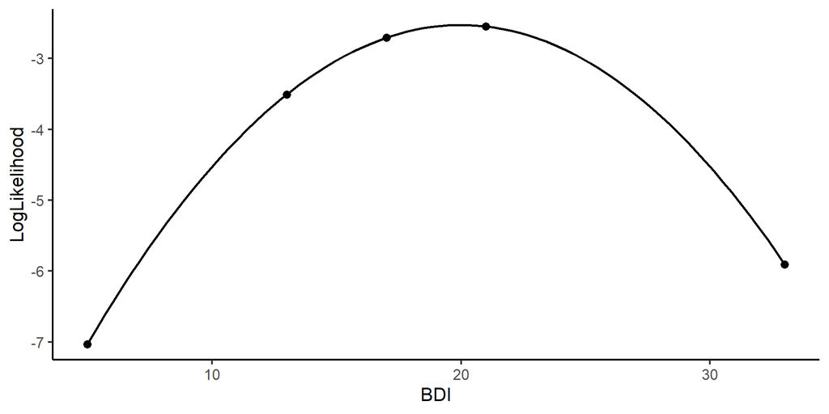

```r
ggplot(data = LL_dat, aes(x = BDI, y = LogLikelihood)) +
  geom_point(size = 3) +
  geom_smooth(method = "lm",formula = y~poly(x,3), se = FALSE, color = "black")
```

## 2.31 Distribution actually unknown!!!

- **We don’t actually know the population values**
  - We draw samples and calculate statistics to **estimate** them
- **Conceptually**, with *maximum likelihood*, we try out different values of the mean and SD to figure out which are **most likely**
  - Which values result in the **highest (log)likelihood**

## 2.32 Assume SD = 5

- Calculate the sample log-likelihood for several potential mean values

```r
mu <- c(10:20)
logL <- c(-42.764,  -40.804,    -39.244,    -38.084,    -37.324,    -36.964,    -37.004,    -37.444,    -38.284,    -39.524,    -41.164)
aud_LL <- data.frame(mu, logL)
aud_LL
```

```
   mu    logL
1  10 -42.764
2  11 -40.804
3  12 -39.244
4  13 -38.084
5  14 -37.324
6  15 -36.964
7  16 -37.004
8  17 -37.444
9  18 -38.284
10 19 -39.524
11 20 -41.164
```

## 2.33 Tangents and minimums again

- **Conceptually**, we try out different values of the mean and SD to figure out which are **most likely**
- **Actually**, we again use **calculus** and **derivatives**
  - Find the **maximum** of the likelihood function

## 2.34 LL function maximized at 15.4

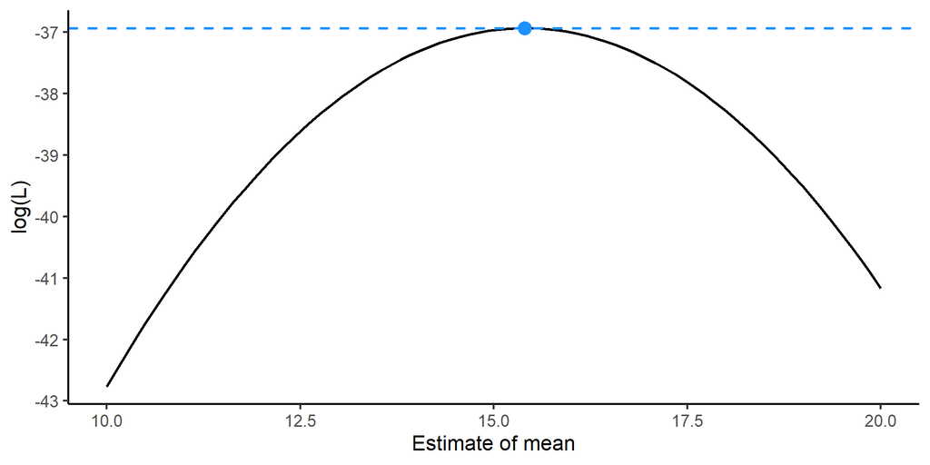

```r
ggplot(data = aud_LL, aes(x = mu, y = logL)) +
  geom_smooth(method = "lm",formula = y~poly(x,3), se = FALSE, color = "black") +
  labs(x = "Estimate of mean", y = "log(L)") +
  geom_hline(yintercept = -36.932, color = "dodgerblue", linetype = "dashed", linewidth = 1) +
  annotate("pointrange", x = 15.4, y = -36.932, ymin = -36.932, ymax = -36.932, color = "dodgerblue", size = 1)
```

## 2.35 Extensions

- **More than 1 parameter** estimated
  - 1 parameter = 2D plots
  - k parameters = (k+1)D plots
- Can’t assume the outcome is from a **normally distriubuted population**
  - Replace **normal likelihood** (i.e., PDF) with appropriate version
  - A **slight** simplification

## 2.36 Extensions

- A variation on maximum likelihood called **full information maximum likelihood** or “FIML” can be used to improve estimation in the presence of **missing data**
  - See the “References” section of the course website

## 2.37 Caveats

- For linear regression, the **likelihood function** is very well-behaved
  - Shaped like upside down “U”
  - Only one maximum value
- For more complex models, the **likelihood function** is less well-behaved
  - Missing data
  - More complex, multivariate models
  - Non-normal outcomes

# 3 Hypothesis testing

## 3.1 Uncertainty

- **Sampling distributions** capture uncertainty in estimate
  - Sample is not population
  - Estimates vary from sample to sample
  - Uncertainty in the point estimate
- Produce quantities like $p$-values, confidence intervals
  - Based on the **standard error**
  - Standard error = standard deviation of sampling distribution

## 3.2 Standard error estimation

- Use the **likelihood function**
  - **Second derivative** of the likelihood function
  - Tells you have quickly the *1st derivative* **changes**
  - Basically, how steep is the maximum likelihood **peak**

## 3.3 Small SE vs large SE

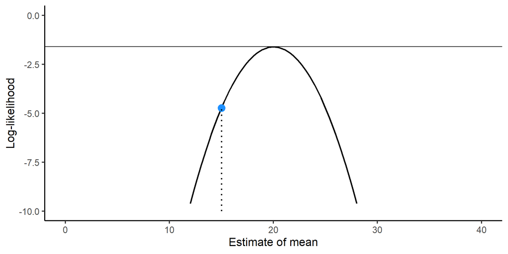

```r
mu <- c(0:40)
L_smallse <- dnorm(mu, 20, 2)
L_largese <- dnorm(mu, 20, 5)
LL_smallse <- log(L_smallse)
LL_largese <- log(L_largese)
LLse_dat <- data.frame(mu, L_smallse, L_largese, LL_smallse, LL_largese)
#round(LLse_dat, 3)
ggplot(data = LLse_dat, aes(x = mu, y = LL_smallse)) +
  geom_smooth(method = "lm",formula = y~poly(x,3), se = FALSE, color = "black") +
  ylim(-10,0) +
  xlim(0,40) +
  annotate("pointrange", x = 15, y = -4.737, ymin = -4.737, ymax = -4.737, color = "dodgerblue", size = 1) +
  geom_segment(x = 15, xend = 15, y = -10, yend = -4.737, linetype = "dotted", linewidth = 1) +
  geom_hline(yintercept = -1.6) +
  labs(x = "Estimate of mean", y = "Log-likelihood")
```

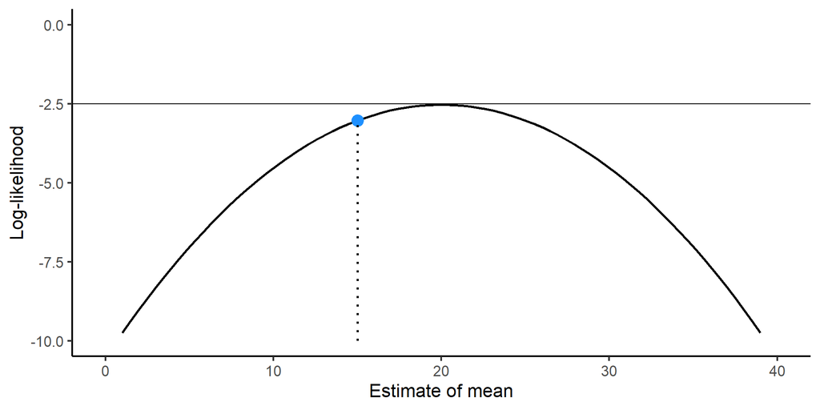

```r
ggplot(data = LLse_dat, aes(x = mu, y = LL_largese)) +
  geom_smooth(method = "lm",formula = y~poly(x,3), se = FALSE, color = "black") +
  ylim(-10,0) +
  xlim(0,40) +
  annotate("pointrange", x = 15, y = -3.028, ymin = -3.028, ymax = -3.028, color = "dodgerblue", size = 1) +
  geom_segment(x = 15, xend = 15, y = -10, yend = -3.028, linetype = "dotted", linewidth = 1) +
  geom_hline(yintercept = -2.5) +
  labs(x = "Estimate of mean", y = "Log-likelihood")
```

## 3.4 Information matrix

- a.k.a. Fisher Information Matrix
- $k \times k$ matrix, where $k$ is the number of parameters estimated
- Values on **diagonal** are **variances** of **parameter estimates**
  - *Square root* to get the **standard error**
- Error about “information matrix” = problem estimating standard errors

## 3.5 Types of significance tests

- Equivalent in very large samples
  - **Wald tests**
  - **Likelihood ratio tests**

## 3.6 Wald tests

- Usually used to test a **single parameter**
  - e.g., regression coefficient
- Divide estimate by its **standard error**
  - Compare to *appropriate hypothesized distribution*
- Regression coefficients use $t$-test, but may see $z$-tests
  - ML estimates are asymptotically normally distributed

## 3.7 Likelihood ratio tests

- Used to test **1 or more** parameters
  - e.g., sets of predictors
  - Similar to `anova()` that we’ve used previously
- Compare likelihoods of two different **nested** models
  - Difference in -2*LL between models $\sim \chi^2(df)$
    - Degrees of freedom = difference in parameters
  - `anova(m1, m2, test = "LRT")`

## 3.8 Degrees of freedom

- Observations are independent pieces of **information**
- Each thing we **estimate** *removes* something
  - One sample $t$-test: Degrees of freedom = $n - 1 = 10 - 1 = 9$
  - Regression coefficient: Degrees of freedom = $n - k - 1$
  - $F$-test of $R^2$: $k$, $n - k - 1$

## 3.9 Example data

- `ICU` data from the **Stat2Data** package

```r
library(Stat2Data)
data(ICU)
head(ICU)
```

```
  ID Survive Age AgeGroup Sex Infection SysBP Pulse Emergency
1  4       0  87        3   1         1    80    96         1
2  8       1  27        1   1         1   142    88         1
3 12       1  59        2   0         0   112    80         1
4 14       1  77        3   0         0   100    70         0
5 27       0  76        3   1         1   128    90         1
6 28       1  54        2   0         1   142   103         1
```

## 3.10 Model 1

- `Age` and `Sex` predict `Pulse`

```r
m1 <- lm(data = ICU, Pulse ~ Age + Sex)
summary(m1)
```

```
Call:
lm(formula = Pulse ~ Age + Sex, data = ICU)

Residuals:
    Min      1Q  Median      3Q     Max
-59.231 -17.730  -4.163  19.440  93.225

Coefficients:
            Estimate Std. Error t value Pr(>|t|)
(Intercept) 95.55647    5.87949  16.253   <2e-16 ***
Age          0.04533    0.09563   0.474    0.636
Sex          2.00005    3.94123   0.507    0.612
---
Signif. codes:  0 '***' 0.001 '**' 0.01 '*' 0.05 '.' 0.1 ' ' 1

Residual standard error: 26.93 on 197 degrees of freedom
Multiple R-squared:  0.0027,    Adjusted R-squared:  -0.007425
F-statistic: 0.2667 on 2 and 197 DF,  p-value: 0.7662
```

## 3.11 Degrees of freedom

- Regression coefficient
  - $b_{Age} = 0.04533, t(197) = 0.474, p = .636$
  - $n - k - 1$ (sample size minus predictors minus 1)
- Overall $F$-test
  - $R^2 = 0.0027, F(2, 197) = 0.2667, p = .7662$
  - Degree of freedom 1: $k$ (number of predictors)
  - Degree of freedom 2: $n - k - 1$ (sample size minus predictors minus 1)

## 3.12 Information matrix

- `vcov()` function in **stats** package (always loaded)
  - Values on main diagonal are **variances**
  - Square root to get standard error

```r
vcov(m1)
```

```
            (Intercept)          Age         Sex
(Intercept)  34.5683578 -0.512491478 -3.81886908
Age          -0.5124915  0.009145049 -0.03621144
Sex          -3.8188691 -0.036211443 15.53330671
```

- $\sqrt{15.53330671}$ = 3.94123, which is standard error for `Sex`

## 3.13 Model 2

- `Age` and `Sex` predict `Pulse`, then add `Infection` and `Emergency`

```r
m2 <- lm(data = ICU, Pulse ~ Age + Sex + Infection + Emergency)
summary(m2)
```

```
Call:
lm(formula = Pulse ~ Age + Sex + Infection + Emergency, data = ICU)

Residuals:
    Min      1Q  Median      3Q     Max
-70.688 -16.922  -3.541  15.705  82.057

Coefficients:
            Estimate Std. Error t value Pr(>|t|)
(Intercept) 85.11154    6.83731  12.448  < 2e-16 ***
Age          0.02128    0.09430   0.226   0.8217
Sex          0.88884    3.77520   0.235   0.8141
Infection   15.52284    3.77981   4.107  5.9e-05 ***
Emergency    7.79833    4.29475   1.816   0.0709 .
---
Signif. codes:  0 '***' 0.001 '**' 0.01 '*' 0.05 '.' 0.1 ' ' 1

Residual standard error: 25.53 on 195 degrees of freedom
Multiple R-squared:  0.1127,    Adjusted R-squared:  0.09446
F-statistic:  6.19 on 4 and 195 DF,  p-value: 0.0001041
```

## 3.14 Information matrix

```r
vcov(m2)
```

```
            (Intercept)          Age         Sex   Infection    Emergency
(Intercept)  46.7487516 -0.535360582 -1.31998556  0.23115884 -16.70442963
Age          -0.5353606  0.008892873 -0.04388807 -0.06836532   0.09389264
Sex          -1.3199856 -0.043888071 14.25216756  0.30122681  -2.30859090
Infection     0.2311588 -0.068365322  0.30122681 14.28699784  -3.28174376
Emergency   -16.7044296  0.093892640 -2.30859090 -3.28174376  18.44486337
```

## 3.15 Likelihood ratio test

- `logLik()` function from **stats** package (always loaded)

```r
logLik(m1)
```

```
'log Lik.' -940.9174 (df=4)
```

```r
logLik(m2)
```

```
'log Lik.' -929.2347 (df=6)
```

- Why different degrees of freedom here?
  - Counts estimating the **variance** of the outcome as well
  - Intercept + number of predictors + variance

## 3.16 Likelihood ratio test

```r
anova(m1, m2, test = "LRT")
```

```
Analysis of Variance Table

Model 1: Pulse ~ Age + Sex
Model 2: Pulse ~ Age + Sex + Infection + Emergency
  Res.Df    RSS Df Sum of Sq  Pr(>Chi)
1    197 142859
2    195 127107  2     15752 5.657e-06 ***
---
Signif. codes:  0 '***' 0.001 '**' 0.01 '*' 0.05 '.' 0.1 ' ' 1
```

```r
-2 * (logLik(m1) - logLik(m2))
```

```
'log Lik.' 23.36533 (df=4)
```

# 4 Next time

## 4.1 Interactions

- Non-additive effects
  - Relationship differs across groups
  - Easy to add to the model
    - Interpretation is more difficult